# DESeq2 Multifactor Analysis Final Project

# Goals for DGE Analysis

The goals for this analysis are to investigate how the gene expression changes based on the mouse model, genotype within the mouse model, and age. Questions to answer: -What genes are differentially expressed due to Mouse Model Alone? -How does aging affect gene expression within each mouse model? -How does the genotype within each mouse model affect gene expression at different time points?

### Import experimental design matrix.

```r
library(DESeq2)
library(pheatmap)
library(dplyr)
library(dendextend)
```

```r
design_matrix<-read.table('/Users/danielaquijano/Documents/GitHub/Transcriptomics-Final-Project-/source_files/Experimental_Design.csv',sep=',',header=TRUE)
```

```r
rownames(design_matrix)<-design_matrix$Sample
design_matrix$Sample<-NULL
```

```r
design_matrix
```

|  | Model | Genotype | Age |
| --- | --- | --- | --- |
| SRR8512301 | rtg4510 | WT | 8 |
| SRR8512302 | rtg4510 | rtg4510 | 8 |
| SRR8512303 | rtg4510 | WT | 2 |
| SRR8512304 | rtg4510 | rtg4510 | 2 |
| SRR8512307 | rtg4510 | WT | 8 |
| SRR8512308 | rtg4510 | rtg4510 | 8 |
| SRR8512309 | rtg4510 | WT | 2 |
| SRR8512310 | rtg4510 | rtg4510 | 2 |
| SRR8512313 | rtg4510 | rtg4510 | 2 |
| SRR8512318 | rtg4510 | WT | 8 |

[output cut: 62 more lines]

Import matrix containing the counts for all samples. These counts represent the forward strand counts since this was a stranded library.

```r
counts_matrix<-read.table("/Users/danielaquijano/Documents/GitHub/Transcriptomics-Final-Project-/Count_Tables/allcounts.csv",sep=',',header=TRUE)
```

```r
counts_matrix
```

| V1 | SRR8512304 | SRR8512310 | SRR8512313 | SRR8512326 | SRR8512332 | SRR8512336 | SRR8512350 | SRR8512435 | SRR8512302 | SRR8512308 | SRR8512319 | SRR8512330 | SRR8512342 | SRR8512348 | SRR8512440 | SRR8512303 | SRR8512309 | SRR8512325 | SRR8512331 | SRR8512335 | SRR8512349 | SRR8512434 | SRR8512301 | SRR8512307 | SRR8512318 | SRR8512324 | SRR8512329 | SRR8512341 | SRR8512347 | … |
| --- | --- | --- | --- | --- | --- | --- | --- | --- | --- | --- | --- | --- | --- | --- | --- | --- | --- | --- | --- | --- | --- | --- | --- | --- | --- | --- | --- | --- | --- | --- |
| ENSMUSG00000000001.4 | 422 | 584 | 530 | 320 | 450 | 463 | 614 | 544 | 584 | 578 | 542 | 592 | 554 | 690 | 713 | 466 | 649 | 514 | 480 | 612 | 522 | 457 | 433 | 321 | 399 | 494 | 497 | 440 | 480 | … |
| ENSMUSG00000000003.13 | 0 | 0 | 0 | 0 | 0 | 0 | 0 | 0 | 0 | 0 | 0 | 0 | 0 | 0 | 0 | 0 | 0 | 0 | 0 | 0 | 0 | 0 | 0 | 0 | 0 | 0 | 0 | 0 | 0 | … |
| ENSMUSG00000000028.12 | 24 | 23 | 30 | 14 | 31 | 27 | 29 | 19 | 33 | 31 | 20 | 31 | 32 | 32 | 28 | 24 | 33 | 20 | 30 | 32 | 35 | 23 | 14 | 15 | 24 | 23 | 23 | 24 | 29 | … |
| ENSMUSG00000000031.13 | 2 | 3 | 1 | 2 | 1 | 1 | 5 | 4 | 3 | 25 | 7 | 6 | 2 | 40 | 23 | 0 | 0 | 5 | 14 | 0 | 4 | 4 | 3 | 1 | 0 | 2 | 0 | 0 | 4 | … |
| ENSMUSG00000000037.14 | 10 | 14 | 7 | 2 | 13 | 9 | 1 | 6 | 12 | 8 | 7 | 11 | 13 | 15 | 6 | 10 | 11 | 6 | 6 | 13 | 18 | 12 | 8 | 10 | 7 | 6 | 10 | 15 | 13 | … |
| ENSMUSG00000000049.9 | 25 | 24 | 30 | 15 | 35 | 35 | 45 | 31 | 30 | 42 | 26 | 39 | 35 | 37 | 25 | 28 | 34 | 56 | 29 | 36 | 21 | 26 | 27 | 22 | 16 | 23 | 28 | 16 | 47 | … |
| ENSMUSG00000000056.7 | 633 | 865 | 913 | 380 | 761 | 762 | 928 | 635 | 668 | 674 | 610 | 574 | 831 | 734 | 728 | 858 | 1326 | 577 | 920 | 1064 | 893 | 581 | 687 | 570 | 842 | 670 | 879 | 840 | 953 | … |
| ENSMUSG00000000058.6 | 327 | 490 | 407 | 283 | 343 | 333 | 444 | 435 | 527 | 488 | 409 | 456 | 436 | 565 | 519 | 328 | 481 | 313 | 419 | 521 | 437 | 330 | 370 | 259 | 308 | 320 | 352 | 335 | 393 | … |
| ENSMUSG00000000078.6 | 652 | 880 | 920 | 480 | 845 | 826 | 950 | 810 | 783 | 732 | 711 | 554 | 872 | 986 | 997 | 706 | 1007 | 738 | 798 | 1419 | 903 | 492 | 736 | 518 | 609 | 797 | 651 | 732 | 852 | … |
| ENSMUSG00000000085.14 | 529 | 725 | 685 | 374 | 606 | 653 | 749 | 629 | 669 | 621 | 556 | 630 | 638 | 717 | 698 | 688 | 917 | 591 | 725 | 919 | 742 | 603 | 543 | 387 | 656 | 548 | 671 | 608 | 758 | … |

[output cut: 990 more lines]

```r
rownames(counts_matrix)<-counts_matrix$V1
counts_matrix$V1<-NULL
```

```r
counts_matrix<-counts_matrix[,order(colnames(counts_matrix))]
```

```r
counts_matrix
```

|  | SRR8512301 | SRR8512302 | SRR8512303 | SRR8512304 | SRR8512307 | SRR8512308 | SRR8512309 | SRR8512310 | SRR8512313 | SRR8512318 | SRR8512319 | SRR8512324 | SRR8512325 | SRR8512326 | SRR8512329 | SRR8512330 | SRR8512331 | SRR8512332 | SRR8512335 | SRR8512336 | SRR8512341 | SRR8512342 | SRR8512347 | SRR8512348 | SRR8512349 | SRR8512350 | SRR8512351 | SRR8512352 | SRR8512353 | … |
| --- | --- | --- | --- | --- | --- | --- | --- | --- | --- | --- | --- | --- | --- | --- | --- | --- | --- | --- | --- | --- | --- | --- | --- | --- | --- | --- | --- | --- | --- | --- |
| ENSMUSG00000000001.4 | 433 | 584 | 466 | 422 | 321 | 578 | 649 | 584 | 530 | 399 | 542 | 494 | 514 | 320 | 497 | 592 | 480 | 450 | 612 | 463 | 440 | 554 | 480 | 690 | 522 | 614 | 244 | 380 | 205 | … |
| ENSMUSG00000000003.13 | 0 | 0 | 0 | 0 | 0 | 0 | 0 | 0 | 0 | 0 | 0 | 0 | 0 | 0 | 0 | 0 | 0 | 0 | 0 | 0 | 0 | 0 | 0 | 0 | 0 | 0 | 0 | 0 | 0 | … |
| ENSMUSG00000000028.12 | 14 | 33 | 24 | 24 | 15 | 31 | 33 | 23 | 30 | 24 | 20 | 23 | 20 | 14 | 23 | 31 | 30 | 31 | 32 | 27 | 24 | 32 | 29 | 32 | 35 | 29 | 6 | 11 | 9 | … |
| ENSMUSG00000000031.13 | 3 | 3 | 0 | 2 | 1 | 25 | 0 | 3 | 1 | 0 | 7 | 2 | 5 | 2 | 0 | 6 | 14 | 1 | 0 | 1 | 0 | 2 | 4 | 40 | 4 | 5 | 3 | 2 | 0 | … |
| ENSMUSG00000000037.14 | 8 | 12 | 10 | 10 | 10 | 8 | 11 | 14 | 7 | 7 | 7 | 6 | 6 | 2 | 10 | 11 | 6 | 13 | 13 | 9 | 15 | 13 | 13 | 15 | 18 | 1 | 1 | 3 | 5 | … |
| ENSMUSG00000000049.9 | 27 | 30 | 28 | 25 | 22 | 42 | 34 | 24 | 30 | 16 | 26 | 23 | 56 | 15 | 28 | 39 | 29 | 35 | 36 | 35 | 16 | 35 | 47 | 37 | 21 | 45 | 1 | 3 | 2 | … |
| ENSMUSG00000000056.7 | 687 | 668 | 858 | 633 | 570 | 674 | 1326 | 865 | 913 | 842 | 610 | 670 | 577 | 380 | 879 | 574 | 920 | 761 | 1064 | 762 | 840 | 831 | 953 | 734 | 893 | 928 | 192 | 304 | 233 | … |
| ENSMUSG00000000058.6 | 370 | 527 | 328 | 327 | 259 | 488 | 481 | 490 | 407 | 308 | 409 | 320 | 313 | 283 | 352 | 456 | 419 | 343 | 521 | 333 | 335 | 436 | 393 | 565 | 437 | 444 | 426 | 644 | 377 | … |
| ENSMUSG00000000078.6 | 736 | 783 | 706 | 652 | 518 | 732 | 1007 | 880 | 920 | 609 | 711 | 797 | 738 | 480 | 651 | 554 | 798 | 845 | 1419 | 826 | 732 | 872 | 852 | 986 | 903 | 950 | 340 | 595 | 361 | … |
| ENSMUSG00000000085.14 | 543 | 669 | 688 | 529 | 387 | 621 | 917 | 725 | 685 | 656 | 556 | 548 | 591 | 374 | 671 | 630 | 725 | 606 | 919 | 653 | 608 | 638 | 758 | 717 | 742 | 749 | 243 | 370 | 225 | … |

[output cut: 990 more lines]

```r
design_matrix<-design_matrix[order(rownames(design_matrix)),]
```

```r
design_matrix
```

|  | Model | Genotype | Age |
| --- | --- | --- | --- |
| SRR8512301 | rtg4510 | WT | 8 |
| SRR8512302 | rtg4510 | rtg4510 | 8 |
| SRR8512303 | rtg4510 | WT | 2 |
| SRR8512304 | rtg4510 | rtg4510 | 2 |
| SRR8512307 | rtg4510 | WT | 8 |
| SRR8512308 | rtg4510 | rtg4510 | 8 |
| SRR8512309 | rtg4510 | WT | 2 |
| SRR8512310 | rtg4510 | rtg4510 | 2 |
| SRR8512313 | rtg4510 | rtg4510 | 2 |
| SRR8512318 | rtg4510 | WT | 8 |

[output cut: 62 more lines]

```r
dds <- DESeqDataSetFromMatrix(countData = counts_matrix,
                              colData = design_matrix,
                              design = ~ Genotype + Age+ Model)
dds
```

```
class: DESeqDataSet
dim: 46075 72
metadata(1): version
assays(1): counts
rownames(46075): ENSMUSG00000000001.4 ENSMUSG00000000003.13 ... N_noFeature
  N_unmapped
rowData names(0):
colnames(72): SRR8512301 SRR8512302 ... SRR8512439 SRR8512440
colData names(3): Model Genotype Age
```

Remove genes with counts less than 10

```r
keep <- rowSums(counts(dds)) >= 10
dds <- dds[keep,]
```

Run DESeq

```r
dds <- DESeq(dds)
```

```
-- replacing outliers and refitting for 34 genes
-- DESeq argument 'minReplicatesForReplace' = 7
-- original counts are preserved in counts(dds)
```

```r
rawcounts.matrix <- counts(dds,normalized=F)
normalizedcounts.matrix <- counts(dds,normalized=T)
class(rawcounts.matrix)
```

```
[1] "matrix" "array"
```

```r
vst_dds <- vst(dds)
dists <- dist(t(assay(vst_dds)))
```

```r
dists
```

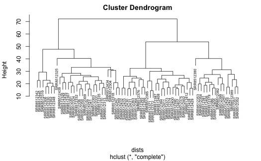

```r
dendogram<-plot(hclust(dists),cex=0.6)
```

```r
labels(dendogram)
```

```
character(0)
```

Trying to rename labels….

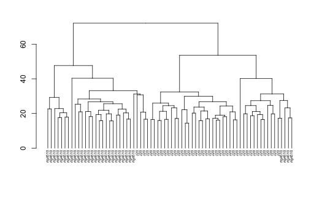

```r
dend <- dists %>%  hclust %>% as.dendrogram
dend %>% set("labels", c(rep('rtg4510',26),rep('J20',42),rep('rtg4510',4))) %>% set("labels_cex", 0.5) %>% plot
```

```r
head(vst_dds)
```

```
class: DESeqTransform
dim: 6 72
metadata(1): version
assays(1): ''
rownames(6): ENSMUSG00000000001.4 ENSMUSG00000000028.12 ... ENSMUSG00000000049.9
  ENSMUSG00000000056.7
rowData names(35): baseMean baseVar ... replace dispFit
colnames(72): SRR8512301 SRR8512302 ... SRR8512439 SRR8512440
colData names(5): Model Genotype Age sizeFactor replaceable
```

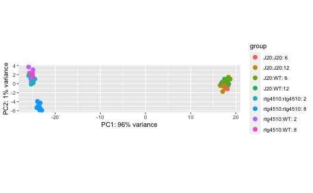

```r
plotPCA(vst_dds,intgroup=c("Model","Genotype","Age"))
```

# Obtain results based on different contrasts

### What genes are differentially expressed due to Mouse Model Alone?

```r
res_1 <- results(dds, contrast = c("Model","rtg4510","J20"))
```

```r
res1_ordered <- res_1[order(res_1$pvalue),]
head(res1_ordered,200)
```

```
log2 fold change (MLE): Model rtg4510 vs J20
Wald test p-value: Model rtg4510 vs J20
DataFrame with 200 rows and 6 columns
                       baseMean log2FoldChange     lfcSE      stat       pvalue
                      <numeric>      <numeric> <numeric> <numeric>    <numeric>
ENSMUSG00000005677.12   328.896        8.26452 0.2131736   38.7689            0
ENSMUSG00000005983.13   246.217        3.72650 0.0742760   50.1710            0
ENSMUSG00000006638.12   132.773        3.38797 0.0803164   42.1827            0
ENSMUSG00000011658.12   445.560        2.93788 0.0712441   41.2368            0
ENSMUSG00000012126.14   246.792        3.01331 0.0779703   38.6469            0
...                         ...            ...       ...       ...          ...
ENSMUSG00000097712.1    74.2415        6.04755 0.2101826   28.7728 4.69241e-182
ENSMUSG00000064368.1  6615.3200        4.05861 0.1414058   28.7019 3.61766e-181
ENSMUSG00000097537.1    54.7733        4.34720 0.1519897   28.6020 6.35047e-180
ENSMUSG00000027536.6    65.8562        4.51330 0.1578768   28.5875 9.60648e-180
ENSMUSG00000032182.12  358.6079        1.49445 0.0522791   28.5861 1.00125e-179
                              padj
                         <numeric>
ENSMUSG00000005677.12            0
ENSMUSG00000005983.13            0
ENSMUSG00000006638.12            0
ENSMUSG00000011658.12            0
ENSMUSG00000012126.14            0
...                            ...
ENSMUSG00000097712.1  5.54399e-180
ENSMUSG00000064368.1  4.25250e-179
ENSMUSG00000097537.1  7.42717e-178
ENSMUSG00000027536.6  1.11788e-177
ENSMUSG00000032182.12 1.15930e-177
```

```r
res_2 <- results(dds, contrast = c("Age","2","8"))
```

```
Error in cleanContrast(object, contrast, expanded = isExpanded, listValues = listValues,  :
  Age is not a factor, see ?results
```

```r
?results
```

#GO-Term Enrichment

Install Mouse annotation library:

```r
BiocManager::install("org.Mm.eg.db")
a
```

```
  There are binary versions available but the source versions are later:
```

|  | binary | source | needs_compilation |
| --- | --- | --- | --- |
| Seurat | 4.1.0 | 4.1.1 | TRUE |
| SeuratObject | 4.0.4 | 4.1.0 | TRUE |

```r
Yes
```

[output not shown]

[output not shown]

[output not shown]

[output cut: 88 more lines]

[output not shown]

[output not shown]

[output not shown]

[output cut: 88 more lines]

[output not shown]

[output not shown]

[output not shown]

[output not shown]

[output not shown]

[output not shown]

[output not shown]

[output cut: 88 more lines]

[output not shown]

[output not shown]

[output not shown]

[output cut: 88 more lines]

[output not shown]

[output not shown]

[output not shown]

[output cut: 88 more lines]

[output not shown]

[output not shown]

[output not shown]

[output cut: 88 more lines]

[output not shown]